# Introduction to Jupyter Notebooks

[Jupyter Notebooks](https://jupyter.org/) are an enviornment allowing you to code and to take notes in one same document. That means that in this notebook you can:

- write cells like this one in [markdown](https://en.wikipedia.org/wiki/Markdown) (try and press `Enter` when this cell is selected, it will show you the code for it... press `Ctrl-Enter` or `Shift-Enter` and it's back to how it was!);
- write code cells like the one just below (press `Ctrl-Enter` or `Shift-Enter` to run it as well):

```python
print("Hello Jupyter!")
```

```
Hello Jupyter!
```

## Shortcuts

The Jupyter environment is full of shortcuts and great things that make your life easier.

A quick list:

- press `Enter` to start typing into a cell, `Escape` to navigate your notebook (you can then press `j` or `k`, or the arrow keys, to go up and down;
- when navigating (not typing in a cell), you can press `a` to create a new cell above, `b` for below;
- if a cell is selected (but you are not typing in it), you can press `m` to turn it into a `markdown` cell, and `y` to make it a code cell;
- if you press `Ctrl-Enter`, you will run the cell and stay on it, whereas if you press `Shift+Enter`, you go one cell below (and if it is the last one, a new one will be created);
- if a cell is selected, you can press `x` to cut it, `c` to copy it, and then `v` to paste after the current cell, and `V` to paste before it;
- **Many** other shortcuts, which you can also customise, check in the menu above "Help" > "Keyboard Shortcuts".

## Markdown

Markdown is an easy way to write text in a web context without going for the full html syntax.

You can check out [this cheatsheet](https://github.com/adam-p/markdown-here/wiki/Markdown-Cheatsheet).

Basic things:

- Separate paragraphs with an empty line, or two spaces at the end of the line;
- italic with `*asterisks*` or `_underscores_`, bold with `**two**` or `__two__`, (the two can be combined);
- lists, numbered or unnumbered, like so:

```
unnumbered list with a line starting with -
numbered list with 1., 2., etc.
```

- code snippets using this the grave accent `, multiline with three of them ```;
- titles (h1-6) using `#` starting the line, from just one to six;
- three stars `***` or dashes `---` give you a horizontal line like tihs one (it needs to be at the start of the line):
- links are generated like so: `[text](link.com)`;
- images similarly: `![image text](image.jpg)`;

For more details, check out the cheatsheet!

# Simple coding

As seen in the videos, any code cell allows you to input code and get results immediately.

```python
x = 10
y = x + 2
y
```

```
12
```

Notice that if you run a cell with a variable at the end of it, it will act like a print out of that variable.

```python
print(y) # same as above, and our y still exist!
```

```
12
```

You can do all sorts of nice things now in Python!

```python
mylist = [1,2,3,4]
mylist_squared = [element**2 for element in mylist] # nice and Pythonic list comprehension syntax
print(mylist_squared)
print(max(mylist_squared)) # the maximum element
```

```
[1, 4, 9, 16]
16
```

When in doubt, ask for help! It can be quite dry at first but if you get used to how it's written, it's a goldmine of information!

```python
help(max)
```

```
Help on built-in function max in module builtins:

max(...)
    max(iterable, *[, default=obj, key=func]) -> value
    max(arg1, arg2, *args, *[, key=func]) -> value

    With a single iterable argument, return its biggest item. The
    default keyword-only argument specifies an object to return if
    the provided iterable is empty.
    With two or more arguments, return the largest argument.
```

Don't ever forget to press the `TAB` button as well, which allows you to access both the autocomplete (for variables, classes and functions names) and methods (in-built functionality from libraries).

In the cell below, put your cursor at the end of each of those, press `TAB` and look at the list of options. (These will only work if you have run the cells defining the variables `mylist` and `mylist_squared` above!)

Beware! These cells are now incomplete, and will throw an error if you run them like that!

```python
my # put your cursor after y and hit `TAB`: you will be able to choose between the two variables starting by these letters
```

```python
mylist. # hitting `TAB` after the . will show all list methods that Python has (many!)
```

## Now a Data Science example!

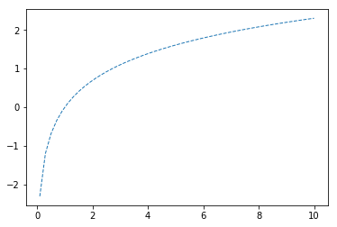

```python
%matplotlib inline

import matplotlib # remember in Python you have to import the relevant libraries

import numpy as np

import matplotlib.pyplot as plt

x = np.linspace(0.1,10) # return evenly spaced numbers over a specified interval, from 0.1 to 10 (see the help below)

line = plt.plot(x, np.log(x),'--',linewidth = 1) # plot these evenly spaced numbers against their logarithm
                                                 # use '--' as line (try with just one for instance),
                                                 # and control the width
```

```python
help(np.linspace)
```

```
Help on function linspace in module numpy.core.function_base:

linspace(start, stop, num=50, endpoint=True, retstep=False, dtype=None)
    Return evenly spaced numbers over a specified interval.

    Returns `num` evenly spaced samples, calculated over the
    interval [`start`, `stop`].

    The endpoint of the interval can optionally be excluded.

    Parameters
    ----------
    start : scalar
        The starting value of the sequence.
    stop : scalar
        The end value of the sequence, unless `endpoint` is set to False.
        In that case, the sequence consists of all but the last of ``num + 1``
        evenly spaced samples, so that `stop` is excluded.  Note that the step
        size changes when `endpoint` is False.
    num : int, optional
        Number of samples to generate. Default is 50. Must be non-negative.
    endpoint : bool, optional
        If True, `stop` is the last sample. Otherwise, it is not included.
        Default is True.
    retstep : bool, optional
        If True, return (`samples`, `step`), where `step` is the spacing
        between samples.
    dtype : dtype, optional
        The type of the output array.  If `dtype` is not given, infer the data
        type from the other input arguments.

        .. versionadded:: 1.9.0

    Returns
    -------
    samples : ndarray
        There are `num` equally spaced samples in the closed interval
        ``[start, stop]`` or the half-open interval ``[start, stop)``
        (depending on whether `endpoint` is True or False).
    step : float, optional
```

[output cut: 17 more lines]

```
    >>> np.linspace(2.0, 3.0, num=5, retstep=True)
    (array([ 2.  ,  2.25,  2.5 ,  2.75,  3.  ]), 0.25)

    Graphical illustration:

    >>> import matplotlib.pyplot as plt
    >>> N = 8
    >>> y = np.zeros(N)
    >>> x1 = np.linspace(0, 10, N, endpoint=True)
    >>> x2 = np.linspace(0, 10, N, endpoint=False)
    >>> plt.plot(x1, y, 'o')
    >>> plt.plot(x2, y + 0.5, 'o')
    >>> plt.ylim([-0.5, 1])
    (-0.5, 1)
    >>> plt.show()
```